# TFIDF_PCA_Kmeans

# Text mining using TF-IDF, PCA and K means

### Today we will be looking at the annual bill board winners to see if there are changes in the billboard winning songs from 1990 to 2018.

1. *Load the libraries*

```r
library(tm)
library(magrittr)
library(tidytext)
library(Matrix)
library(factoextra)
library(stringr)
library(readr)
library(tidyr)
library(tidyverse)
```

```r
library(ggplot2)
```

2. *Load in the txt files*

```r
files_list <- list.files(path = ".", recursive = TRUE,
                         pattern = "*.txt$", full.names = TRUE)
songs <- lapply(files_list, read_file) %>%
  unlist(.)
```

3. *Change format into corpus*

```r
df <- as.data.frame(songs)
corpus_song <- Corpus(VectorSource(df$songs))
```

4. *Cleaning up some punctuations*

```r
song_words <- corpus_song %>%
  tm_map(removePunctuation)  %>%
  tm_map(removeNumbers)
```

5. *Document Term Matrix*

```r
dtm <- DocumentTermMatrix(song_words)
inspect(dtm)
```

```
## <<DocumentTermMatrix (documents: 23, terms: 1105)>>
## Non-/sparse entries: 2284/23131
## Sparsity           : 91%
## Maximal term length: 20
## Weighting          : term frequency (tf)
## Sample             :
##     Terms
## Docs all and for hey know that the yeah you your
##   1    1  10  14   0   13    2   3    3  45   19
##   14   5  14   2   6    3   11  26   95   4    5
##   17   0   5   1   1    1    5  22    3   9   32
##   19   0   4   6  65   18    4   7    1  46    8
##   21   9  12   2   0    1    7  10    2  31    2
##   23   0   0   0   1    0    0   0    2   0    0
##   3    1  11   4   1    3    2  16    0  54    1
##   6    0  11   0   0    4    6  29    0   6    1
##   7    3   6   0  11    0    0   2    0   5    0
##   9    1   1   6   0    9    9   5    5  30    5
```

6. Now that the text files are prepared, we will now move on to the analysis

### TF-IDF

1. *Tabulating the Term Frequencies*

```r
doc_tf <- apply(as.matrix(dtm), 2, function(word) {word/sum(word)})
```

2. *Create the IDF function to load the algorithm*

```r
idf <- function(doc) {
  return(log2( length(doc) + 1 / nnzero(doc)) )
}
```

3. *Obtain IDF*

```r
doc_idf <- apply(as.matrix(dtm), 1, idf)
```

4. *Obtain TFIDF*

```r
docs_tfidf <- doc_tf * doc_idf
```

### PCA

1. *Conduct the PCA using the tfidf results*

```r
docs_pca <- prcomp(docs_tfidf, scale = T)
```

2. *Drawing the plots with eigenvalues*

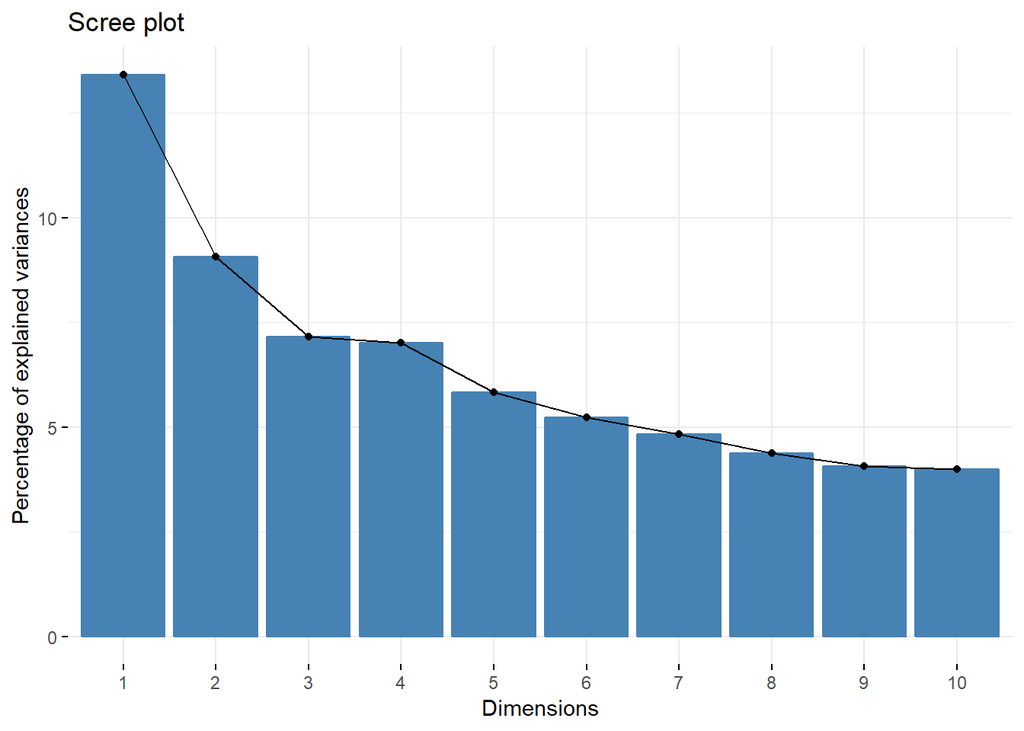

```r
fviz_eig(docs_pca)
```

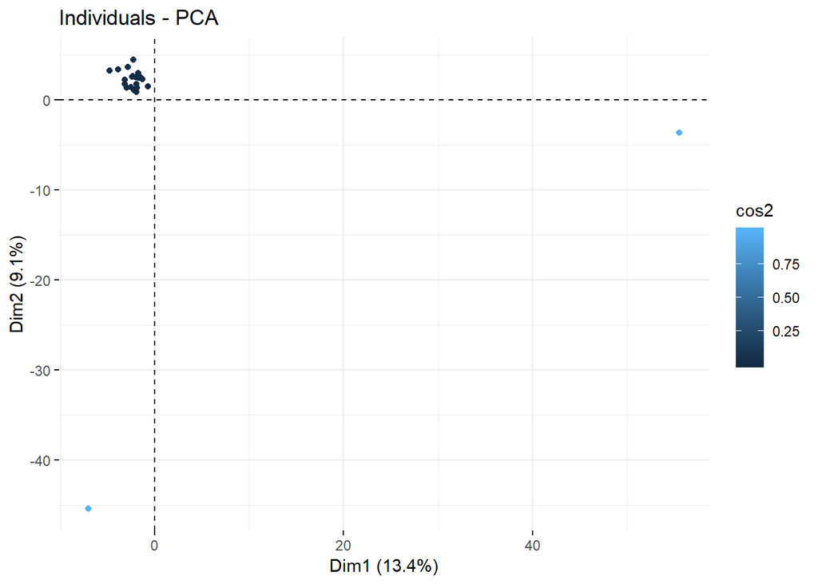

```r
fviz_pca_ind(docs_pca, geom.ind = c("point"), col.ind = "cos2")
```

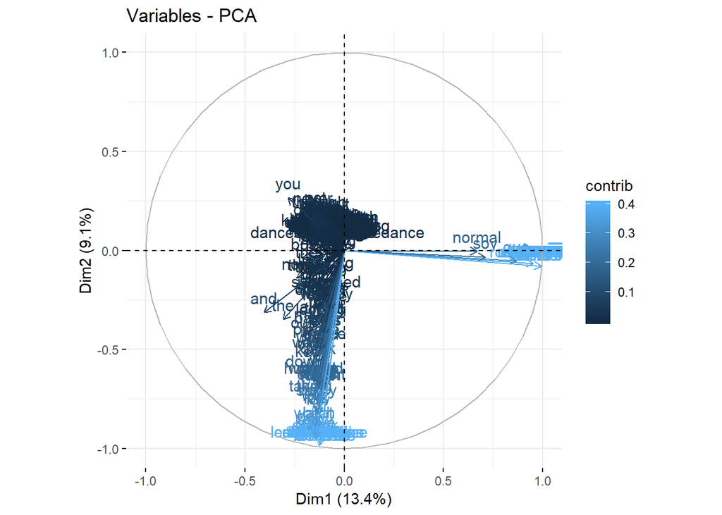

```r
fviz_pca_var(docs_pca, col.var = "contrib")
```

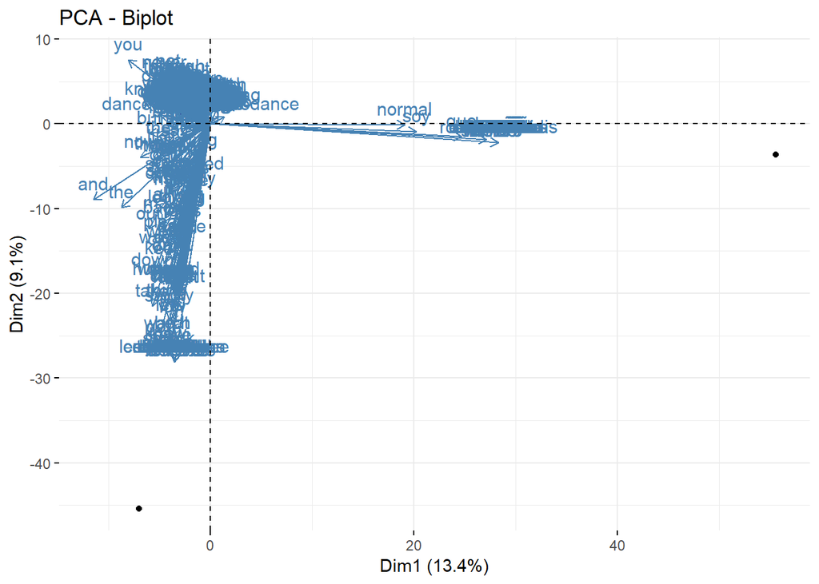

```r
fviz_pca_biplot(docs_pca, geom.ind = "point")
```

3. *Save the individual PCA results into separate variables*

```r
docs_eig <- get_eig(docs_pca)
docs_var <- get_pca_var(docs_pca)
docs_ind <- get_pca_ind(docs_pca)
```

### K means clustering

1. *K means*

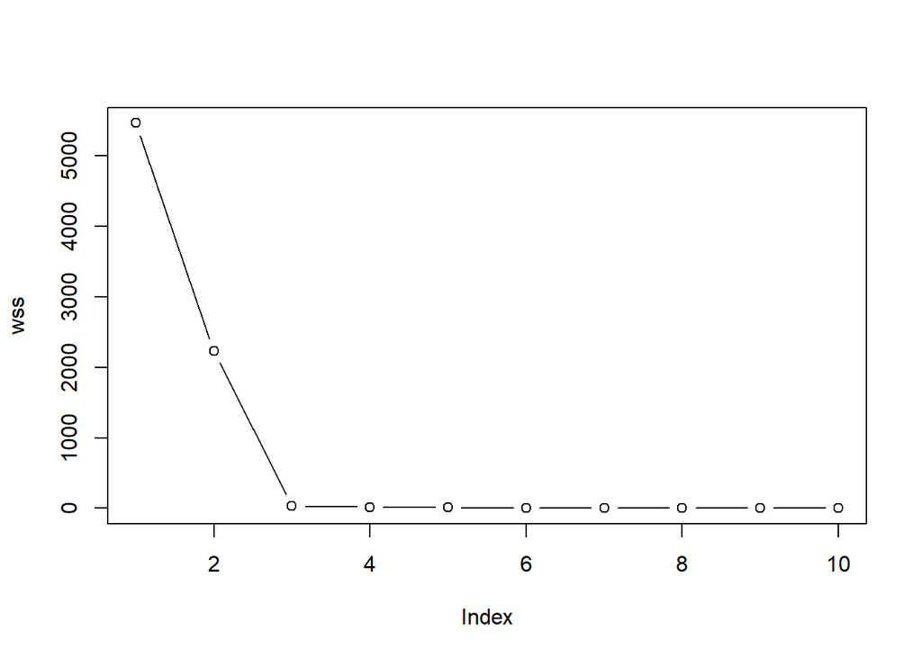

```r
ind_coord2 <- docs_ind$coord[,1:2]
wss <- c()
for (i in 1:10) {
  wss[i] <- kmeans(ind_coord2, i)$tot.withinss
}
plot(wss, type = "b")
```

2. *Clustering*

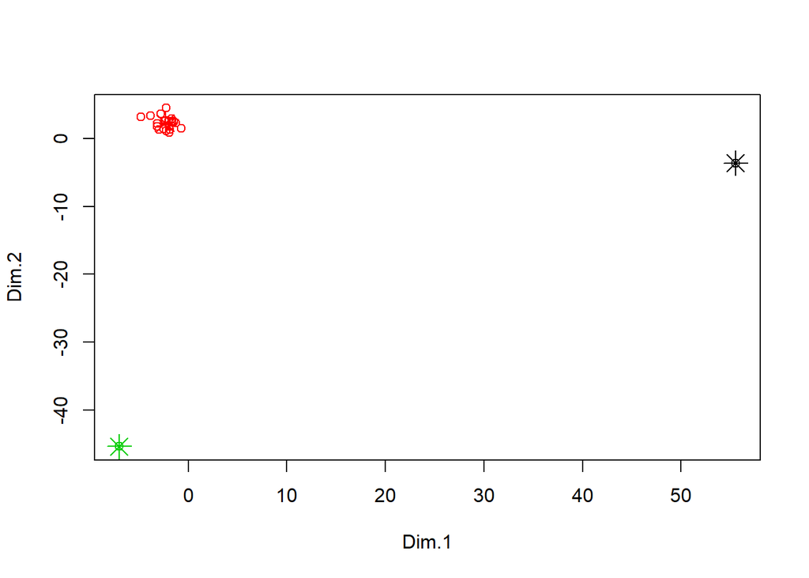

```r
km <- kmeans(ind_coord2, 3)
plot(ind_coord2, col = km$cluster)
points(km$centers, col = 1:3, pch = 8, cex = 2)
```

The green point is Usher’s Yea in 2004. I have no clue why in particular the lyrics are different.

So even though the analysis is complete, it is not meaningful, so we should it again.

Therefore, I think I will run the analysis again without despacito. So it will become looking at the differences in English Billboard songs.

### New plots

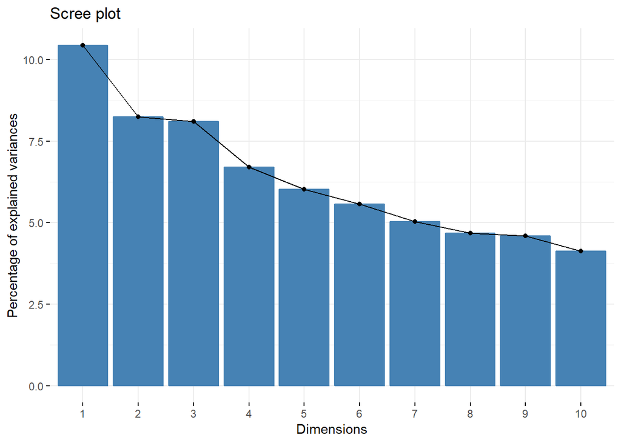

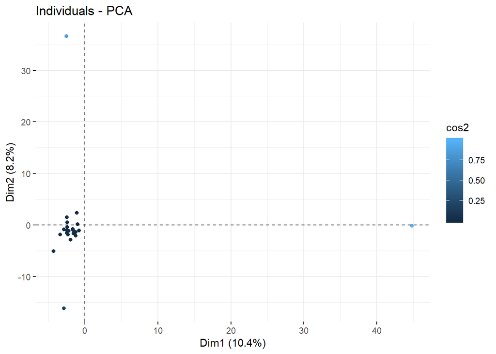

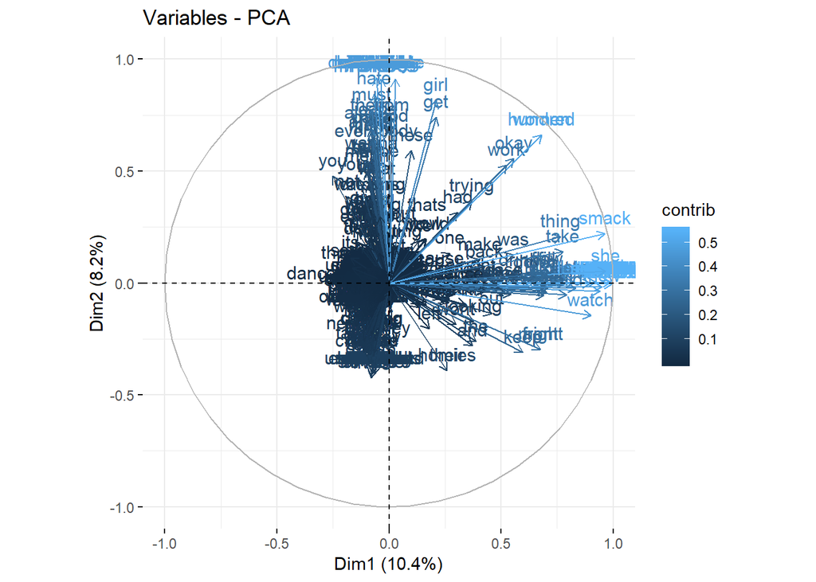

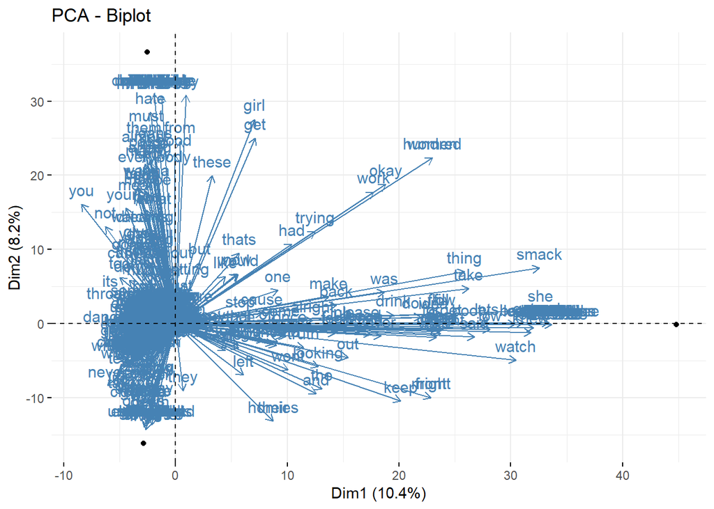

### K means

```r
ind_coord2 <- docs_ind$coord[,1:2]
print(ind_coord2)
```

```
##
## Docs      Dim.1       Dim.2
##   1  -2.4111386   0.5044312
##   2  -2.8628546  -0.8407139
##   3  -1.5405115  -1.6475582
##   4  -2.2386786  -1.1616586
##   5  -2.4438823  -1.5636542
##   6  -2.8503308 -16.1452415
##   7  -1.6140888  -0.9988483
##   8  -4.2827056  -5.1134020
##   9  -2.4554964   1.4917744
##   10 -2.4916441  -1.0575473
##   11 -1.2496975  -2.0695270
##   12 -2.3335549  -1.8561169
##   13 -2.3990623  -0.4428921
##   14 44.8032177  -0.1632970
##   15 -1.9680739  -2.8908025
##   16 -0.7792102  -1.0829912
##   17 -1.0855013   2.3215398
##   18 -1.2411302  -1.3715612
##   19 -2.5261240  36.6457638
##   20 -1.6825892  -0.7898324
##   21 -3.3640669  -1.8782583
##   22 -0.9828760   0.1103934
```

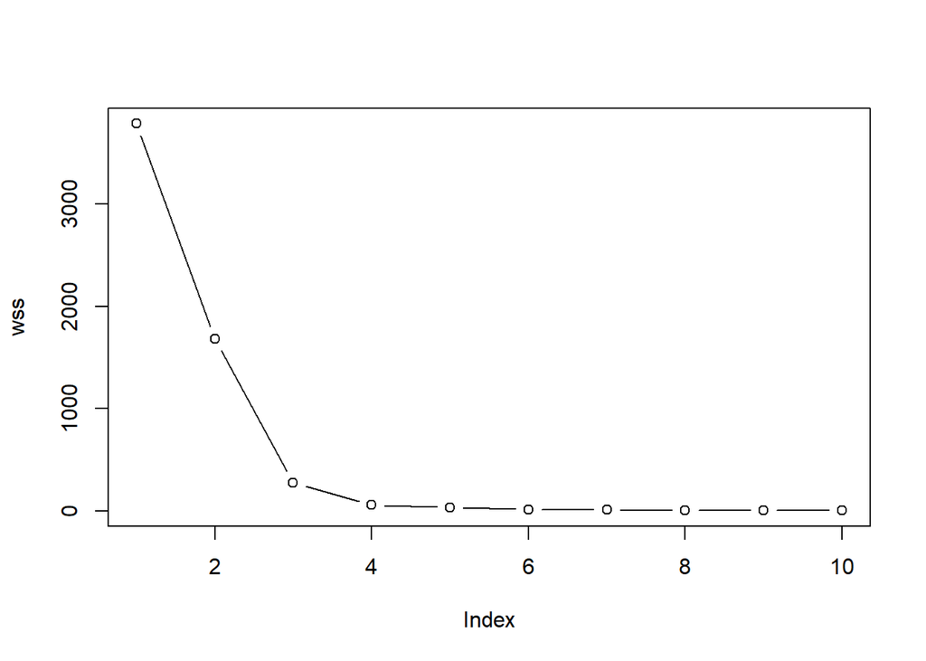

[figure not shown]

```r
wss <- c()
for (i in 1:10) {
  wss[i] <- kmeans(ind_coord2, i)$tot.withinss
}
plot(wss, type = "b")
```

This time Robin Thicke’s blurred lines was a distinct group of its own. The usage of words appears to be more sexual than the rest of the songs. Probably explaining the difference.

I suspected that the tf-idf ==0 words are affecting the results but when I tried deleting them, I can’t seem to find them at all. I believe the songs seem to vary too much to find meaningful groups to provide any kind of conclusion.

Also, I feel that the dataset is too small to derive any meaningful conclusions.

### tidydata and plotting

```r
inspect(dtm)
```

```
## <<DocumentTermMatrix (documents: 22, terms: 965)>>
## Non-/sparse entries: 2135/19095
## Sparsity           : 90%
## Maximal term length: 20
## Weighting          : term frequency (tf)
## Sample             :
##     Terms
## Docs all and for hey know that the yeah you your
##   1    1  10  14   0   13    2   3    3  45   19
##   14   5  14   2   6    3   11  26   95   4    5
##   15   1   3   0   0    3    2  11    0  12    7
##   17   0   5   1   1    1    5  22    3   9   32
##   19   0   4   6  65   18    4   7    1  46    8
##   21   9  12   2   0    1    7  10    2  31    2
##   3    1  11   4   1    3    2  16    0  54    1
##   6    0  11   0   0    4    6  29    0   6    1
##   7    3   6   0  11    0    0   2    0   5    0
##   9    1   1   6   0    9    9   5    5  30    5
```

```r
terms <- Terms(dtm)
head(terms)
```

```
## [1] "all"    "and"    "anyone" "are"    "around" "baby"
```

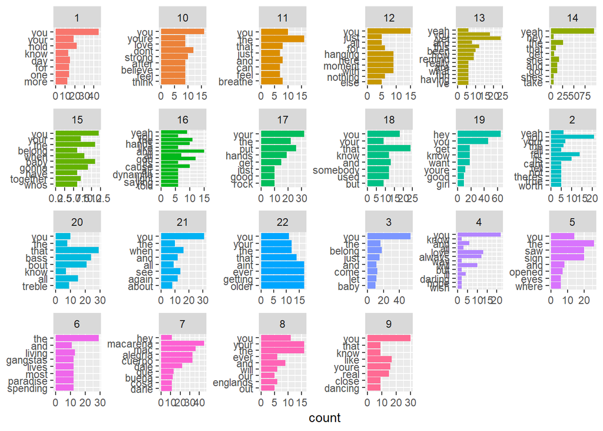

```r
songs_tidy <- tidy(dtm)

songs_tidy %>%
  arrange(desc(count)) %>%
  mutate(term = factor(term, levels = rev(unique(term)))) %>%
  group_by(document) %>%
  top_n(8) %>%
  ungroup %>%
  ggplot(aes(term, count, fill = document)) +
  geom_col(show.legend = FALSE) +
  labs(x = NULL, y = "count") +
  facet_wrap(~document, ncol = 6, scales = "free") +
  coord_flip()
```

So I tried looking at the most frequent words that appear in each songs, but it doesn’t seem to help as well. There are words that are frequent like “your” but they are not frequent enough to be taken out. So… I guess this is one of the limitations of TF-IDF, when the texts files are too diverse to have repeating words.